# Data Visualization with R

# 2.2 Specifying the parameters

We now want the x-values of the plot to indicate the year in which the Chinese government committed to delivering the aid financing (`commitment_year`), and the y-values to represent the number of projects the Chinese government committed to (`n_projects`).

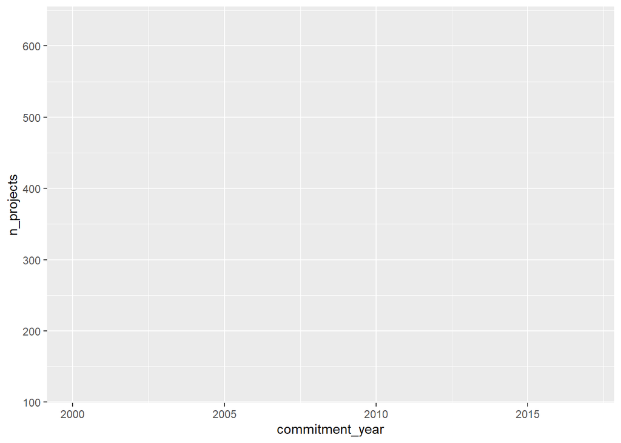

```r
aiddata_yearly %>%
  ggplot(mapping = aes(x = commitment_year,
                       y = n_projects))
```

The updated plot should now contain axis labels, tick marks and labels, and grid lines. It’s time to add some geometric shapes to show the data.

# 2.3 Adding geometric shapes

The ggplot2-package offers a wide range of different geometric shapes. In the following we will focus on bar plots (e.g. `geom_bar`, `geom_col`), line plots (e.g. `geom_line`, `geom_smooth`, `geom_area`), and scatterplots (e.g. `geom_point`).

# 2.3.1 Bar plots with geom_col

We will now visualize a bar plot with the x-values representing the commitment year (`commitment_year`), and the y-values representing the number of projects committed to (`n_projects`). Therefore we simply add a function specifying the desired geometric shape, in this case `geom_col`, with a `+`.

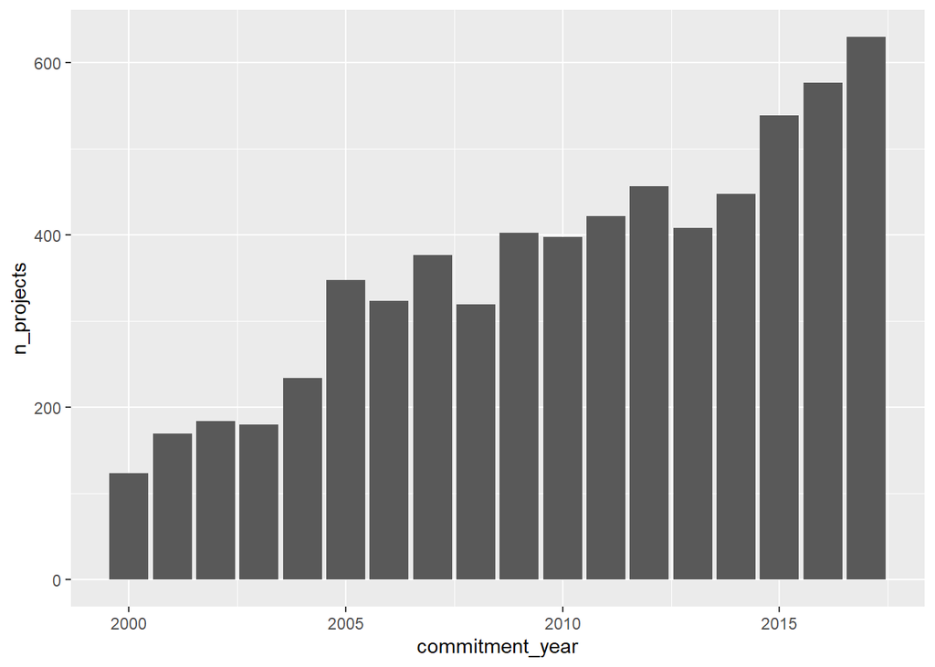

```r
aiddata_yearly %>%
  ggplot(mapping = aes(x = commitment_year,
                       y = n_projects)) +
  geom_col()
```

# 2.3.2 Scatterplots

`Geom_point` allows us to visualize a simple scatterplot with the data points being dependent on the values on the x- and the y-axis.

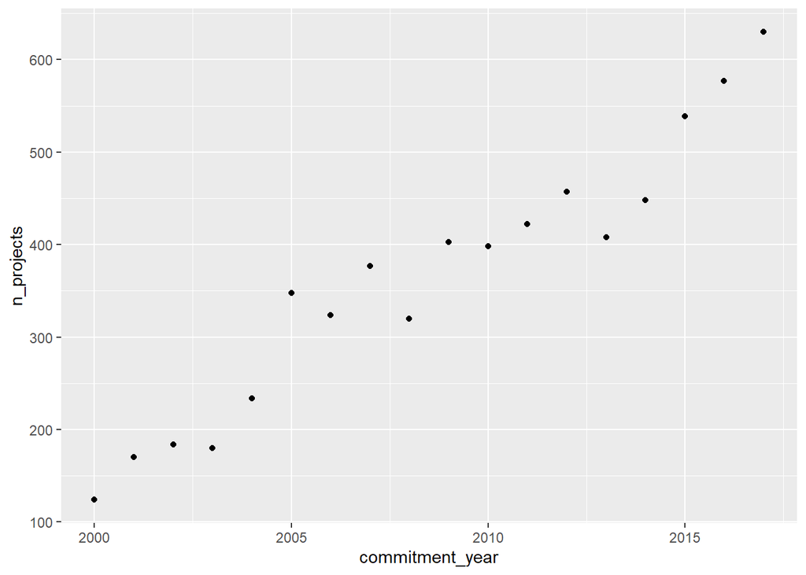

```r
aiddata_yearly %>%
  ggplot(mapping = aes(x = commitment_year,
                       y = n_projects)) +
  geom_point()
```

# 2.3.3 Line plots with geom_line und geom_smooth

With `geom_line` we can visualize a simple line plot, since the function connects observations in order of the variable on the x-axis. Beyond, `geom_smooth` displays smoothed conditional means that can help us to identify trends in data. By default, it also shows confidence intervals - these can be omitted using the `se = FALSE`- command.

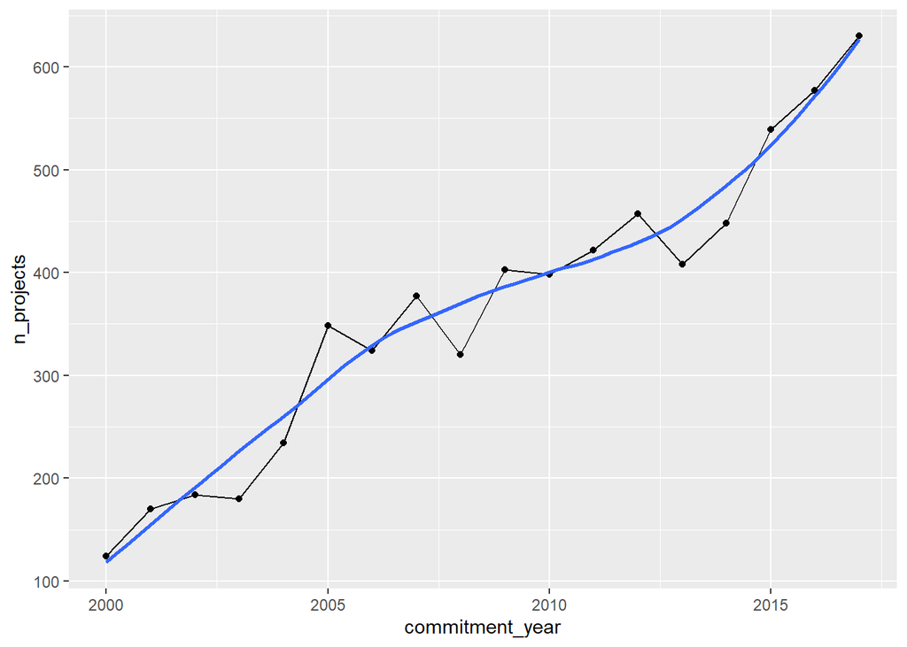

```r
aiddata_yearly %>%
  ggplot(mapping = aes(x = commitment_year,
                       y = n_projects)) +
  geom_point() +
  geom_line() +
  geom_smooth(se = FALSE)
```

# 2.4 Exercise No. 1

Now, start creating some plots yourself. Again, we want to display the years on the x-axis. On the y-axis, we now want to visualize the amount of development finances committed to by the Chinese government (`amount_bn_total`).

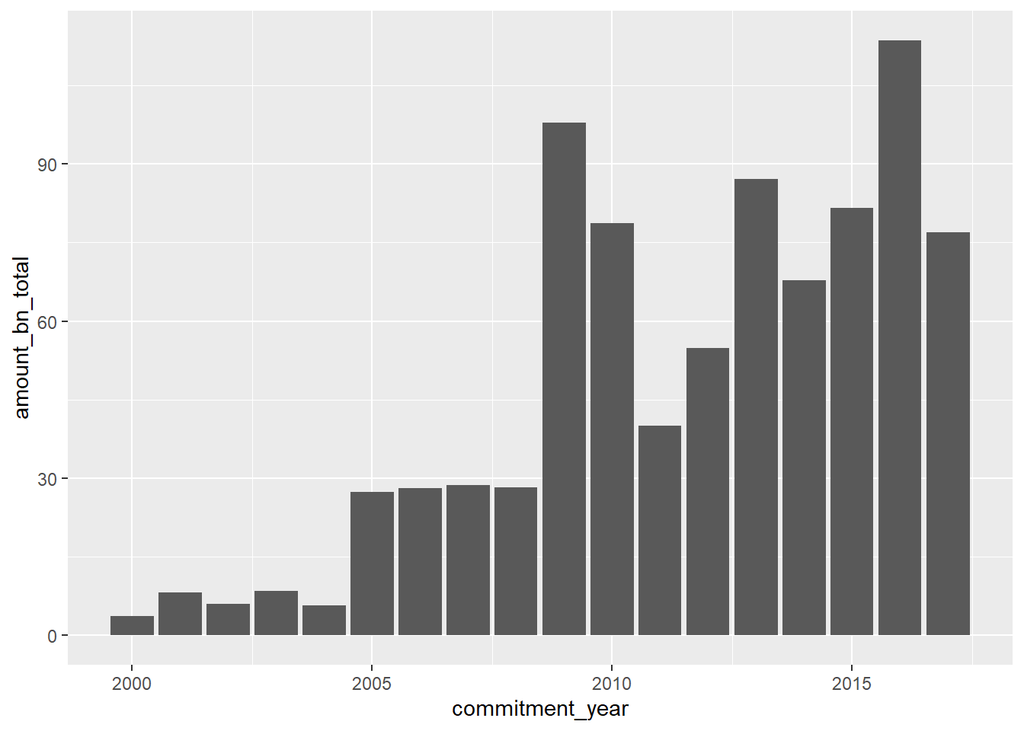

```r
# Bar plot
aiddata_yearly %>%
  ggplot(mapping = aes(x = commitment_year,
                       y = amount_bn_total)) +
  geom_col()
```

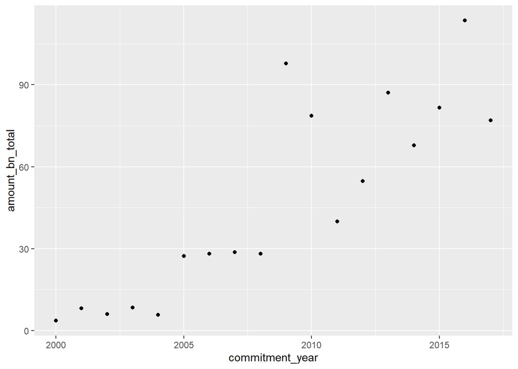

```r
# Scatterplot
aiddata_yearly %>%
  ggplot(mapping = aes(x = commitment_year,
                       y = amount_bn_total)) +
  geom_point()
```

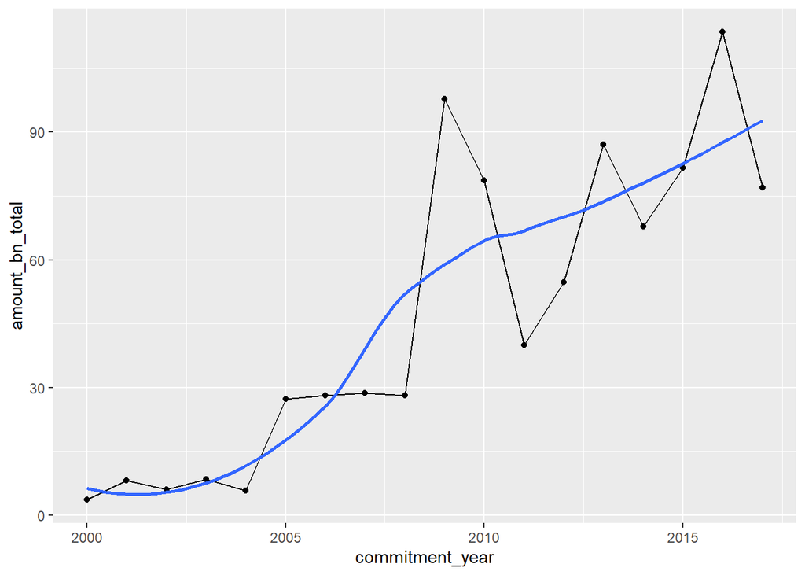

```r
# Line plot
aiddata_yearly %>%
  ggplot(mapping = aes(x = commitment_year,
                       y = amount_bn_total)) +
  geom_point() +
  geom_line() +
  geom_smooth(se = FALSE)
```

If you have finished early, feel free to play around with some other geometric shapes. To have a glimpse at all the possibilities ggplot2 offers, take a look at the ‘Cheatsheet’ provided in the folder.

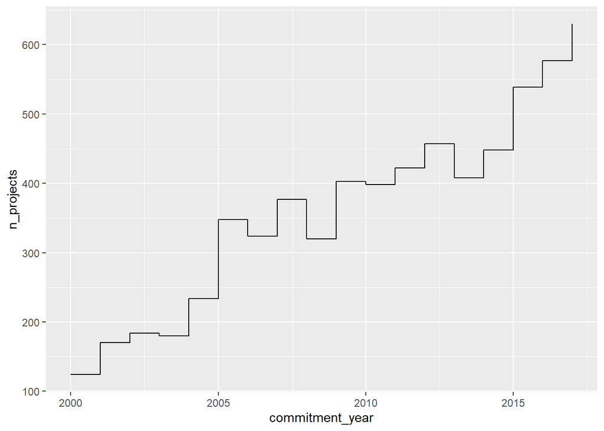

```r
# Maybe step plot could be a handy visualization for the association between year and project number?
aiddata_yearly %>%
  ggplot(mapping = aes(x = commitment_year,
                       y = n_projects)) +
  geom_step()
```

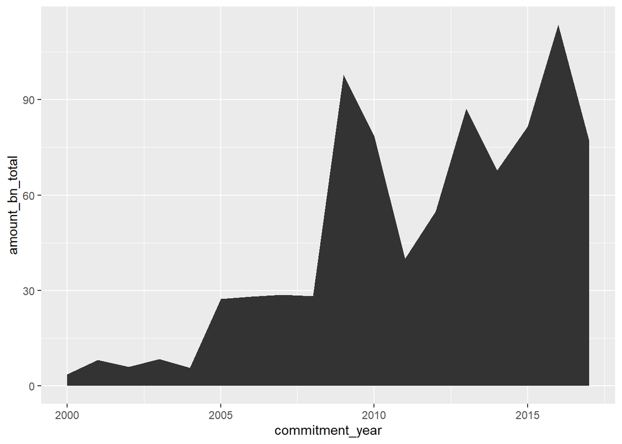

```r
# Maybe an area plot could be an alternative to the line plot for displaying the changes in the amount of aid transfers over time?
aiddata_yearly %>%
  ggplot(mapping = aes(x = commitment_year,
                       y = amount_bn_total)) +
  geom_area()
```

# 3. Adding information and first refinements

# 3.1 Adding information

We now turn to a more fine-grained version of the data set provided by AidData which, besides the sole number of projects or the amount of aid, contains quite some interesting additional information such as the recipient, the recipient region, the intent and the targeted sector.

# 3.1.1 Colors

There are two commands with which you can introduce colors into your plot: `color =` and `fill =`, both of which have to be specified in the `aes()`-function. While `color =` colorizes lines according to a given parameter, `fill =` colorizes/fills respective areas in the plot. In the following, we will use the `fill =`-command since it is more suitable for bar plots. The usage of `color =` is analogous to `fill =`.

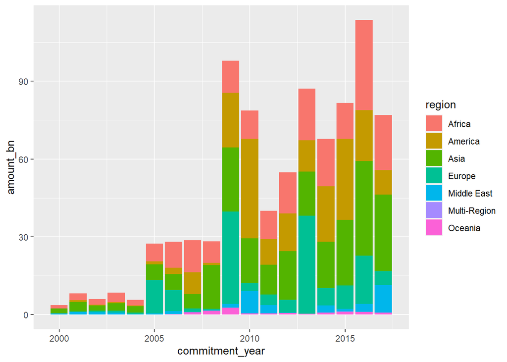

```r
aiddata_red %>%
  ggplot(aes(x = commitment_year,
             y = amount_bn,
             fill = region)) + # note that the 'fill ='-command is included in the 'aes()'-function
  geom_col()
```

# 3.1.2 Facets

Our dataset i.a. contains information on the purpose of financial transfers (e.g. development, commercial, etc.). We can introduce this information into our plot by using the `facet_wrap`-function. For each manifestation of a discrete variable that we specify by using `~` inside `facet_wrap()`, a separate panel is created in the plot. By default, `facet_wrap()` uses the same scale for each panel. Often times, this is appropriate and makes comparisons easier. In our case, however, the amounts spent for `Representational` purposes are so small, that the respective panel needs a different scale on the y-axis. By setting `scale = "free"`, `ggplot2` uses the most appropriate scale for each panel.

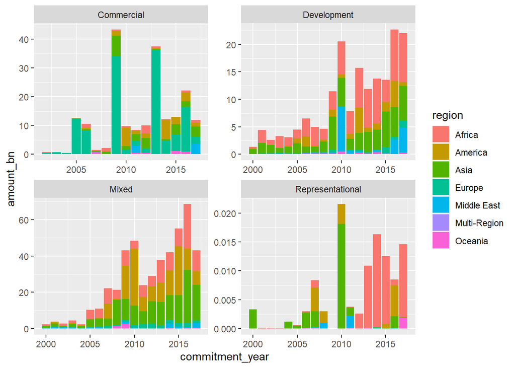

```r
aiddata_red %>%
  ggplot(aes(x = commitment_year,
             y = amount_bn,
             fill = region)) +
  geom_col() +
  facet_wrap(~ intent,
             scale = "free")
```

# 3.2 First refinements

The plots we have created so far might contain and convey most of the relevant information. But they are not very informative and, above all, quite ugly.

# 3.2.1 Themes

Themes can help us to easily alter the looks of our plot. Luckily, `ggplot2` already contains some prefabricated themes such as `theme_classic()` or `theme_minimal()` which help us to brush up the looks of our plot. There is also the `ggthemes`-package which contains some beautiful additional themes, such as those used by ‘The Economist’ or ‘The Wall Street Journal’.

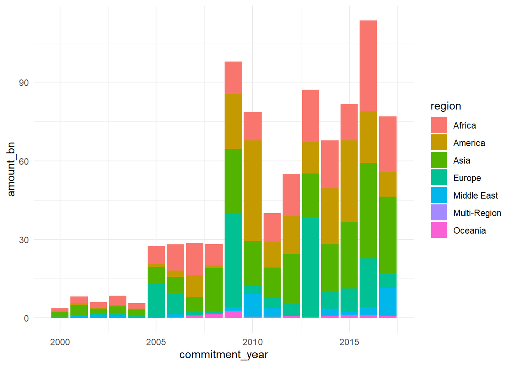

```r
aiddata_red %>%
  ggplot(aes(x = commitment_year,
             y = amount_bn,
             fill = region)) +
  geom_col() +
  theme_minimal()
```

# 3.2.2 Adding labs

The plot itself is beginning to look quite nice. However, without appropriate annotation, it is still hard to grasp what it is about. To fix this issue, we use `labs()` to add titles for the axes, a plot title and subtitle, and a caption.

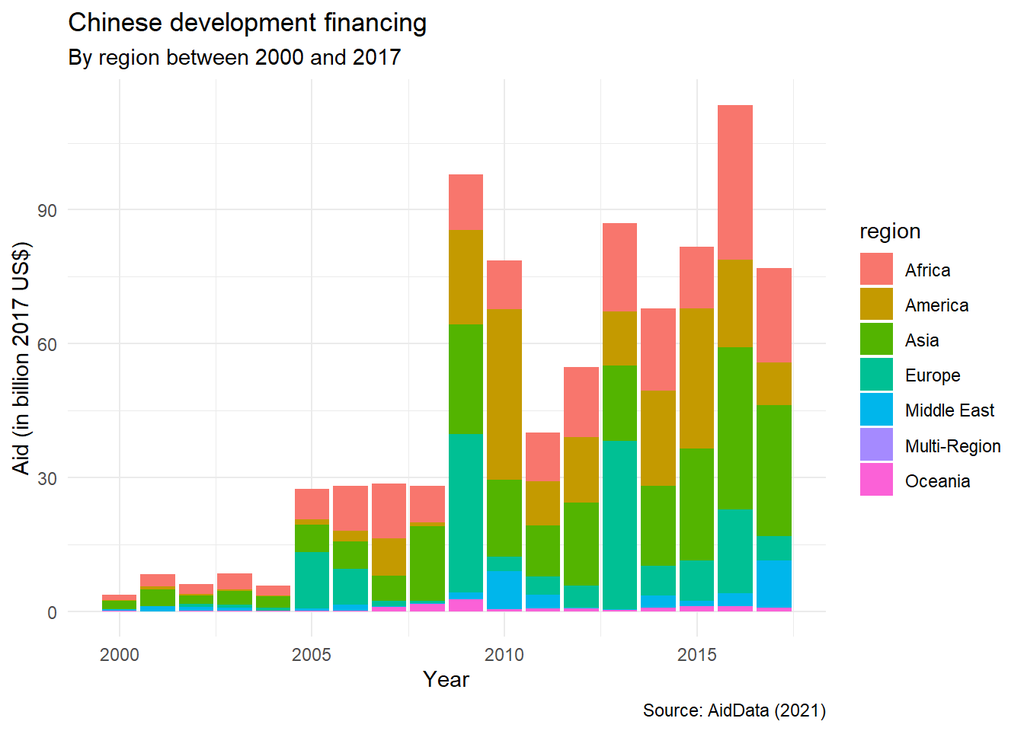

```r
aiddata_red %>%
  ggplot(aes(x = commitment_year,
             y = amount_bn,
             fill = region)) +
  geom_col() +
  labs(x = "Year", # renaming the x-axis
       y = "Aid (in billion 2017 US$)", # renaming the y-axis
       title = "Chinese development financing", # adding a title to the plot
       subtitle = "By region between 2000 and 2017", # adding a subtitle to the plot
       caption = "Source: AidData (2021)") + # adding a caption to the plot
theme_minimal()
```

# 3.2.3 Manually adjusting the theme

Despite using `theme_minimal()`, there remain a number of tweaks that could make our plot look even nicer. We can thus specify `theme()` AFTER `theme_minimal()` to make some manual adjustments. These include changes to the look of both title (`plot.title`) and subtitle(`plot-subtitle`), the removal of the legend’s title (`legend.title`) and it’s relocation (`legend.position`) to the bottom of the plot. To simply omit (NON-DATA) components of the plot, we use `element_blank`, while making changes to text components requires the command `element_text`.

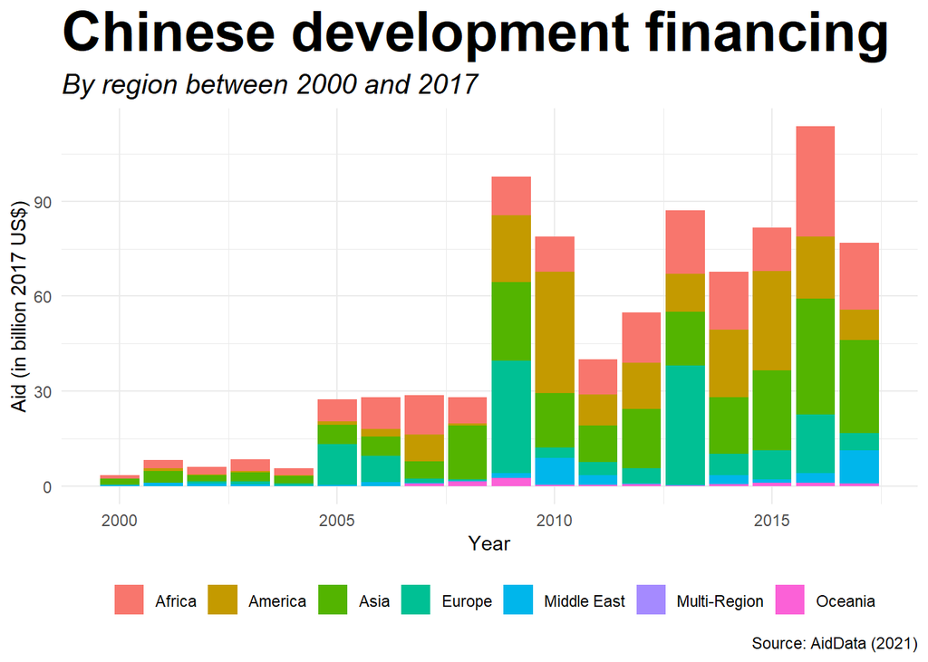

```r
aiddata_red %>%
  ggplot(aes(x = commitment_year,
             y = amount_bn,
             fill = region)) +
  geom_col() +
  labs(x = "Year",
       y = "Aid (in billion 2017 US$)",
       title = "Chinese development financing",
       subtitle = "By region between 2000 and 2017",
       caption = "Source: AidData (2021)") +
  theme_minimal() +
  theme(plot.title = element_text(face = "bold", size = 30), # font face becomes "bold", resizes the text
        plot.subtitle = element_text(face = "italic", size = 15), # font face becomes "italic", resizes the text
        legend.title = element_blank(), # omits the legend title
        legend.position = "bottom") + # relocates the legend to the bottom of the plot
  guides(fill = guide_legend(nrow = 1)) # additional command setting the number of rows in the legend to one (we use the 'fill =' because the color, and thus the legend, are based on the 'fill = recipient_region'-command above)
```

There are more functions that are used for making changes to the theme. With `element_rect` we can change the looks of borders and backgrounds (e.g. the background of the plot), while `element_lines` allows us to make changes to (NON-DATA) lines in the plot (e.g. axis or grid lines).

# 3.3 Exercise No. 2

Please create a bar plot with `geom_col()` that, analogously to the plot above, displays the amount of aid per year, however, now by sector instead of region.

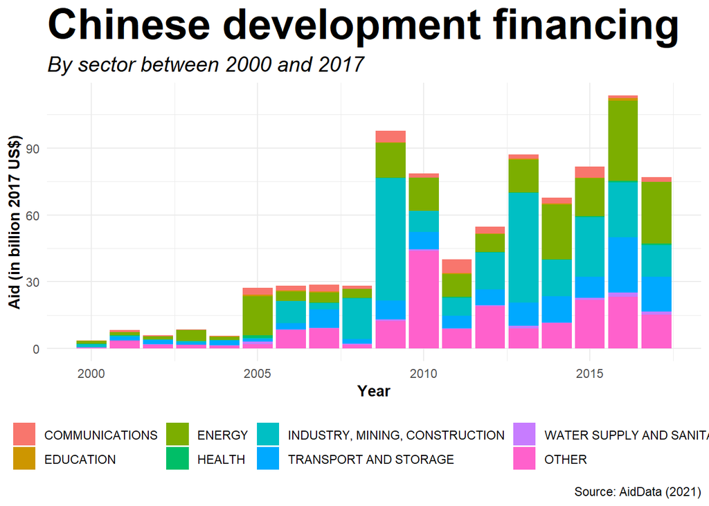

```r
aiddata_red %>%
# First, specify the aesthetics to be displayed in the plot
  ggplot(aes(x = commitment_year,
             y = amount_bn,
             fill = sector)) +
# Specify the geometric shape to be used for the plot (bar plot)
  geom_col() +
# Now, specify the axis titles (x and y) as well as title, subtitle and caption (careful: now the colors no longer represent regions, but the sector of the aid transfer)
  labs(x = "Year",
       y = "Aid (in billion 2017 US$)",
       title = "Chinese development financing",
       subtitle = "By sector between 2000 and 2017",
       caption = "Source: AidData (2021)") +
# Select a theme that builds the basis for our polishing
  theme_minimal() +
# Now, refine the look of the title, the subtitle and the axis titles (hint: 'axis.title ='), omit the legend title and place the legend at the bottom of the plot
  theme(plot.title = element_text(face = "bold", size = 30),
        plot.subtitle = element_text(face = "italic", size = 15),
        legend.title = element_blank(),
        legend.position = "bottom",
        axis.title = element_text(face = "bold")) +
# Last but not least, set the number of rows in the legend to two
  guides(fill = guide_legend(nrow = 2))
```

If you have finished early, feel free to explore and modify some extra themes that are provided by the `ggthemes`-package such as `theme_wsj()`, `theme_economist()` or `theme_fivethirtyeight()`. Below, switching from `theme_minimal` to `theme_wsj` has totally messed up the plot. Can you find a way to modify the code in such a way, that it looks decent again? Hint: besides altering the given functions, also take a look at `plot-caption =` and `legend.text =` (and how to alter text sizes there).

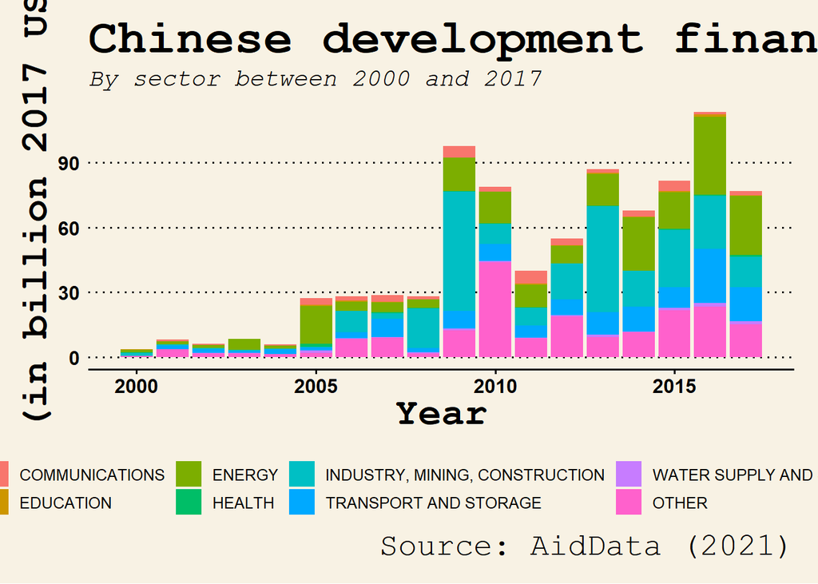

```r
aiddata_red %>%
 ggplot(aes(x = commitment_year,
             y = amount_bn,
             fill = sector)) +
  geom_col() +
  labs(x = "Year",
       y = "Aid (in billion 2017 US$)",
       title = "Chinese development financing",
       subtitle = "By sector between 2000 and 2017",
       caption = "Source: AidData (2021)") +
  theme_wsj() +
  theme(plot.title = element_text(face = "bold", size = 30),
        plot.subtitle = element_text(face = "italic", size = 15),
        legend.title = element_blank(),
        legend.position = "bottom",
        axis.title = element_text(face = "bold")) +
  guides(fill = guide_legend(nrow = 2))
```

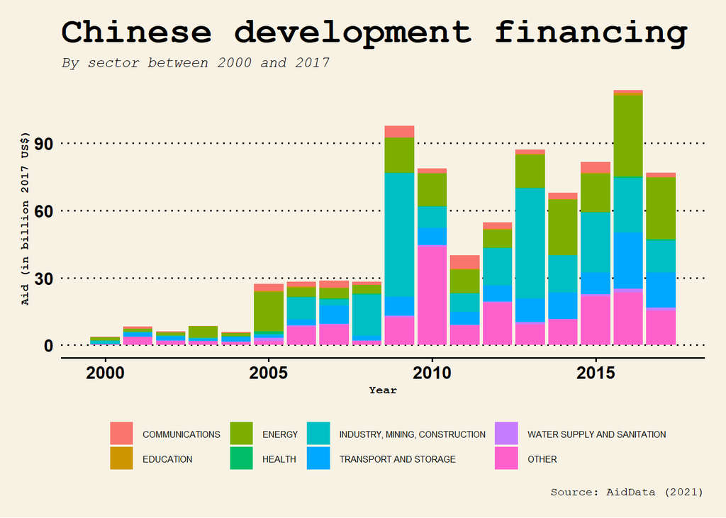

```r
# Possible solution
aiddata_red %>%
 ggplot(aes(x = commitment_year,
             y = amount_bn,
             fill = sector)) +
  geom_col() +
  labs(x = "Year",
       y = "Aid (in billion 2017 US$)",
      title = "Chinese development financing",
       subtitle = "By sector between 2000 and 2017",
       caption = "Source: AidData (2021)") +
  theme_wsj() +
  theme(plot.title = element_text(face = "bold", size = 25),
        plot.subtitle = element_text(face = "italic", size = 10),
        plot.caption = element_text(size = 8),
        legend.title = element_blank(),
        legend.position = "bottom",
        legend.text = element_text(size = 6),
        axis.title = element_text(face = "bold", size = 8)) +
  guides(fill = guide_legend(nrow = 2))
```

# 4. Altering scales

Two important parameters that `ggplot2` allows us to alter are axis scales (x- and y-axis) as well as color scales that define which colors are used in the plot.

# 4.1 Axis scales

To begin with, we can make changes to the x-axis by using the `scale_x_...`-functions. Depending on the variable displayed on the x-axis, we use different specifications of the function: e.g. `scale_x_discrete` for discrete variables, `scale_x_continuous` for continuous variables, `scale_x_date` for dates, and so on … The exact same applies for the `scale_y_...`-functions (e.g. `scale_y_discrete`, …). These functions now allow us to modify the limits of the scales (`limits =` or `expand =`) or the breaks to be displayed (e.g. `breaks =` or `n.breaks =`). Depending on which of the functions we have to pick to fit our variables, we might have to supply slightly different arguments. E.g. see the arguments provided in the `scale_x_date`-function, where we use `date_breaks =` instead of `breaks =`.

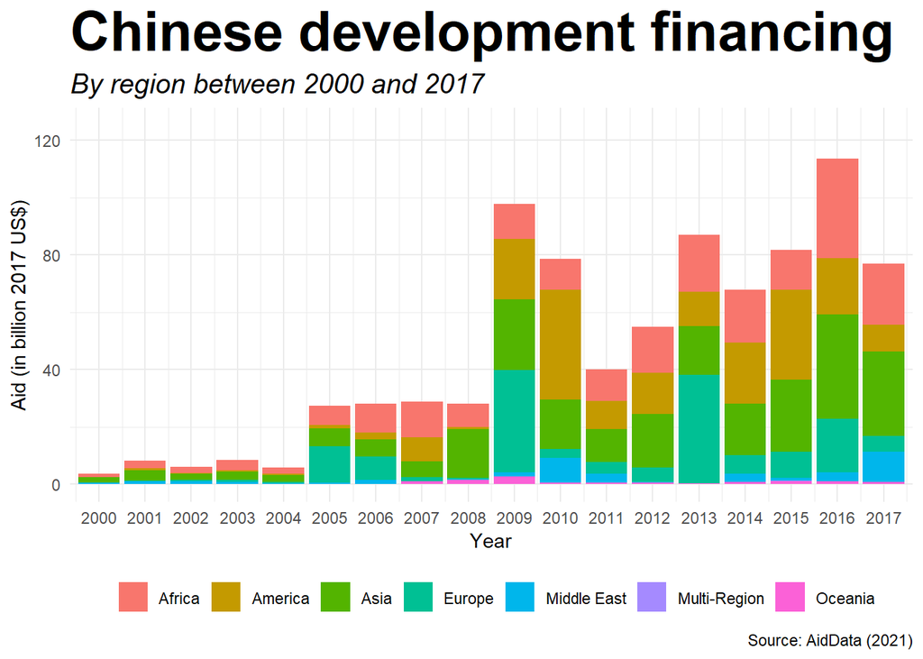

```r
aiddata_red %>%
  ggplot(aes(x = commitment_year,
             y = amount_bn,
             fill = region)) +
  geom_col() +
  labs(x = "Year",
       y = "Aid (in billion 2017 US$)",
       title = "Chinese development financing",
       subtitle = "By region between 2000 and 2017",
       caption = "Source: AidData (2021)") +
  scale_x_date(date_breaks = "1 year",
               date_labels = "%Y",
               expand = expansion(mult = c(0.01, 0.01))) +
  scale_y_continuous(n.breaks = 5,
                     limits = c(0, 125)) +
  theme_minimal() +
  theme(plot.title = element_text(face = "bold",
                                  size = 30),
        plot.subtitle = element_text(face = "italic",
                                     size = 15),
        legend.title = element_blank(),
        legend.position = "bottom") +
  guides(fill = guide_legend(nrow = 1))
```

# 4.2 Color scales

As we have seen so far, when we specify colors in the `aes`-function (in our case with the `fill =`-command), `ggplot2` chooses a certain set of colors by default to execute the command. However, colors are a meaningful aspect of data visualization. Thus, to make our visualization as informative as possible, we should manually adjust the color palette to our needs and the data. For that purpose we can use the functions `scale_color_manual` or `scale_fill_manual` respectively.

Two famous coloring packages are `RColorBrewer` and `viridisLite` which provide color palettes that are designed for different purposes and data types (such as discrete vs. continuous variables). `RColorBrewer` even comes along with a website (https://colorbrewer2.org/) that helps us find the appropriate color palette for our visualization attempt. The two packages are put to use by replacing `scale_color_manual`/`scale_fill_manual` with `scale_color_brewer`/`scale_fill_brewer` or `scale_color_viridis`/`scale_fill_viridis`.

In the following, we have used `RColorBrewer` and a color palette that, thanks to its contrasts, is especially suitable for qualitative scales (“Set1”).

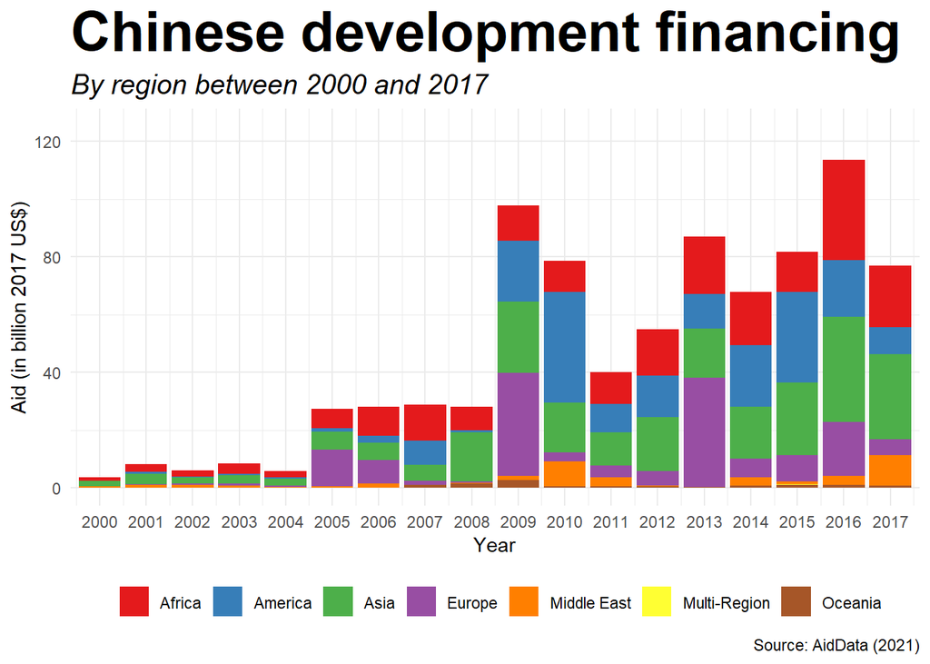

```r
aiddata_red %>%
  ggplot(aes(x = commitment_year,
             y = amount_bn,
             fill = region)) +
  geom_col() +
  labs(x = "Year",
       y = "Aid (in billion 2017 US$)",
       title = "Chinese development financing",
       subtitle = "By region between 2000 and 2017",
       caption = "Source: AidData (2021)") +
  scale_x_date(date_breaks = "1 year",
               date_labels = "%Y",
               expand = expansion(mult = c(0.01, 0.01))) +
  scale_y_continuous(n.breaks = 5,
                     limits = c(0, 125)) +
  scale_fill_brewer(palette = "Set1") +
  theme_minimal() +
  theme(plot.title = element_text(face = "bold",
                                  size = 30),
        plot.subtitle = element_text(face = "italic",
                                     size = 15),
        legend.title = element_blank(),
        legend.position = "bottom") +
  guides(fill = guide_legend(nrow = 1))
```

# 4.4 Exercise No. 3

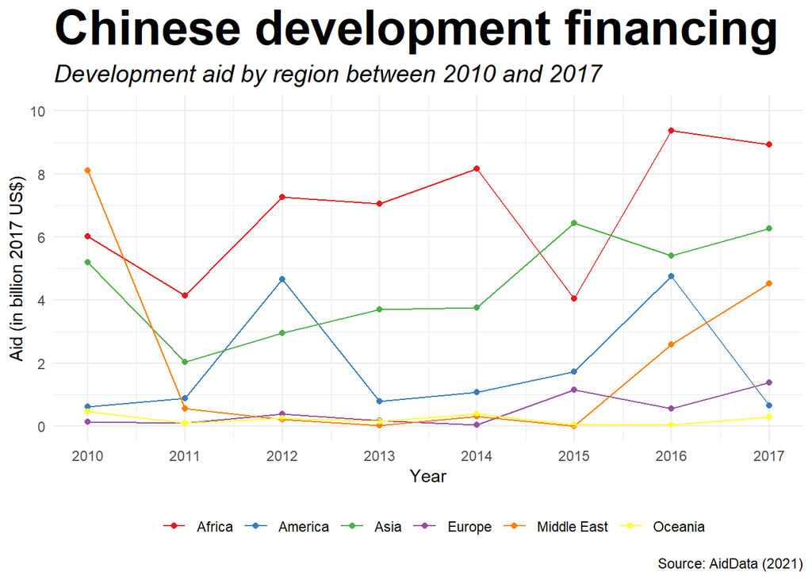

```r
# We need some minor prior data wrangling to have the data ready for our desired plot
aiddata_red %>%
  filter(intent == "Development",
         region != "Multi-Region",
         commitment_year >= "2010-01-01") %>%
  group_by(commitment_year, region) %>%
  summarise(amount_bn_dev = sum(amount_bn)) %>%
# Here begins the actual plotting
  ggplot(aes(x = commitment_year,
             y = amount_bn_dev,
             color = region)) +
  geom_point() +
  geom_line() +
  labs(x = "Year",
       y = "Aid (in billion 2017 US$)",
       title = "Chinese development financing",
       subtitle = "Development aid by region between 2010 and 2017",
       caption = "Source: AidData (2021)") +
# Our x-axis is based on a date-time scale. Thus we need to use scale_x_date(). Specify it, so that date_breaks represent one year and the date_labels indicate only the year
  scale_x_date(date_breaks = "1 year",
               date_labels = "%Y") +
# Our y-axis is based on a continuous scale, namely the amount of financial aid in billion. Define it, so that we have 6 breaks on a scale from 0 to 10
   scale_y_continuous(n.breaks = 6,
                     limits = c(0, 10)) +
# Now, we want to manually adapt the color scale. We want to do this by using the `RColorBrewer`-package and it's palette called "Set1". CAREFUL, we have used the "color ="-argument above, wherefore "scale_fill_brewer()" doesn't work anymore
   scale_color_brewer(palette = "Set1") +
  theme_minimal() +
  theme(plot.title = element_text(face = "bold",
                                  size = 30),
        plot.subtitle = element_text(face = "italic",
                                     size = 15),
        legend.title = element_blank(),
        legend.position = "bottom") +
  guides(color = guide_legend(nrow = 1))
```

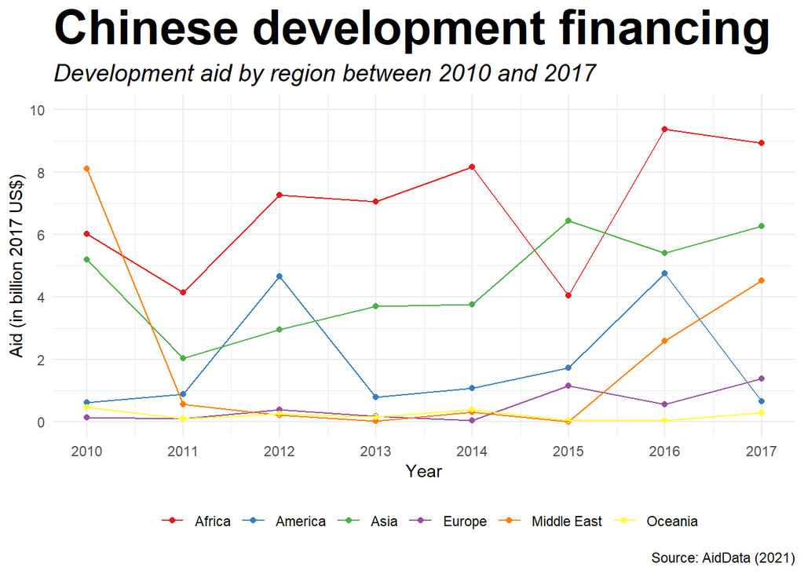

```r
# Possible solution
aiddata_red %>%
  filter(intent == "Development",
         region != "Multi-Region",
         commitment_year >= "2010-01-01") %>%
  group_by(commitment_year, region) %>%
  summarise(amount_bn_dev = sum(amount_bn)) %>%
# Here begins the actual plotting
  ggplot(aes(x = commitment_year,
             y = amount_bn_dev,
             color = region)) +
  geom_point() +
  geom_line() +
  labs(x = "Year",
       y = "Aid (in billion 2017 US$)",
       title = "Chinese development financing",
       subtitle = "Development aid by region between 2010 and 2017",
       caption = "Source: AidData (2021)") +
# Our x-axis is based on a date-time scale. Thus we need to use scale_x_date(). Specify it, so that date_breaks represent one year and the date_labels indicate only the year
  scale_x_date(date_breaks = "1 year",
               date_labels = "%Y") +
# Our y-axis is based on a continuous scale, namely the amount of financial aid in billion. Define it, so that we have 6 breaks on a scale from 0 to 10
   scale_y_continuous(n.breaks = 6,
                     limits = c(0, 10)) +
# Now, we want to manually adapt the color scale. We want to do this by using the `RColorBrewer`-package and it's palette called "Set1". CAREFUL, we have used the "color ="-argument above, wherefore "scale_fill_brewer()" doesn't work anymore
   scale_color_brewer(palette = "Set1") +
  theme_minimal() +
  theme(plot.title = element_text(face = "bold",
                                  size = 30),
        plot.subtitle = element_text(face = "italic",
                                     size = 15),
        legend.title = element_blank(),
        legend.position = "bottom") +
  guides(color = guide_legend(nrow = 1))
```

The styling we we have resorted to for our plotting today is just one out of infinite options for how to make your data visually appealing. In the following you might want to try to develop your very own style. Feel free to again visualize over-time variance in financing activities that have a clear-cut development `intent` between 2010 and 2017 by `region`.

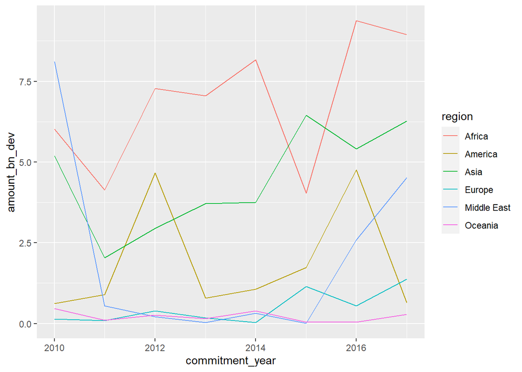

```r
aiddata_red %>%
  filter(intent == "Development",
         region != "Multi-Region",
         commitment_year >= "2010-01-01") %>%
  group_by(commitment_year, region) %>%
  summarise(amount_bn_dev = sum(amount_bn)) %>%
# Here begins the actual plotting
 ggplot(aes(x = commitment_year,
             y = amount_bn_dev,
             color = region)) +
  geom_line()
```